# Flexible Damage Functions

Author

James Rising, Sebastian Cadavid Sanchez, Climate Impact Lab

Published

April 30, 2026

## 0.1 Agriculture: Soy Country

Flexible damage function parameters at the Country level.

**Change in soy yields (log change in yields) under full adaptation**

**Outcome units:** `physical` — log change in soy yield (population-weighted to country)

$$D_{it} = (\alpha_i T_t + \beta_i T_t^2) \cdot Y_{it}^{\gamma}$$

where $\gamma$ is the income elasticity (fitted globally), $\alpha_i$ is the linear coefficient, and $\beta_i$ is the quadratic coefficient.

# 1 Global Estimation

## 1.1 Income Elasticity Estimation

The income elasticity $\gamma$ is estimated using a fixed-effects regression:

$$y_{it} = \gamma \cdot \log(Y_{it}) + \mu_{g(i,T)} + \nu_t + \varepsilon_{it}$$

where $\mu_{g(i,T)}$ are region-by-temperature-bin fixed effects and $\nu_t$ are year fixed effects.

Table 1: Income Elasticity (Gamma) Estimation Results

| Statistic | Value |
| --- | --- |
| Income elasticity ($\gamma$) | -0.3008 |
| Standard error | 1.25e-02 |
| 95% CI | [-0.3253, -0.2763] |
| R-squared | 0.5843 |
| Observations | 2,828,704 |
| Regions | 136 |
| Gamma quantiles | 19 |

# 2 Parameter Distributions

## 2.1 8-Panel Summary

Row 1: gamma, alpha, beta, rsqr1. Row 2: rho, zeta, eta, rsqr2.

```
Using median gamma: -0.300758, 136 rows (of 2,584 total)
```

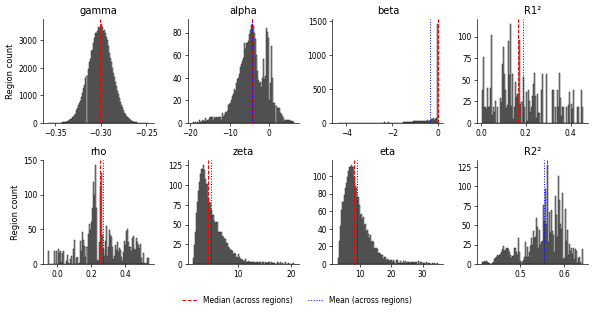

Figure 1: Distribution of Regional Parameters

## 2.2 Projection Equation and Parameter Definitions

The estimated parameters are used to project damages via Monte Carlo sampling:

$$D_{it}^k = (\hat{\alpha}_{ik} T_t + \hat{\beta}_{ik} T_t^2) Y_{it}^{\hat{\gamma}_k} + \hat{\theta}_{ik} T_t Y_{it}^{\hat{\gamma}_k} + \hat{\phi}_{it}^k$$

where $k$ indexes the Monte Carlo draw. The parameters in each row of the output CSV control distinct components of this equation:

- **gamma**: income elasticity $\hat{\gamma}_k$, one of 19 quantile values drawn from $N(\hat{\gamma}, SE(\hat{\gamma}))$
- **alpha, beta**: linear and quadratic temperature coefficients; $\hat{\alpha}_{ik}$ and $\hat{\beta}_{ik}$ are drawn from the joint normal defined by the VCV below
- **sigma11, sigma12, sigma22**: variance-covariance matrix of $(\alpha, \beta)$, used for joint uncertainty sampling
- **rho**: correlation between regional and global polynomial residuals $\rho_i$, used to maintain spatial covariance across regions in Monte Carlo draws
- **zeta**: temperature-dependent error scale $\zeta_{ik}$; the run-specific error term $\hat{\theta}_{ik}$ is drawn from $N(0, \zeta_{ik})$
- **eta**: residual noise standard deviation $\eta_{ik}$; the annual noise $\hat{\phi}_{it}^k$ is drawn from $N(0, \eta_{ik})$
- **rsqr1, rsqr2**: polynomial fit quality and error model fit, respectively

## 2.3 Summary Statistics

Table 2: Regional Parameter Summary

[output not shown]

# 3 Spaghetti Curves

Regional damage function curves showing D(T) = αT + βT² for sampled regions.

[interactive chart not shown]

Figure 2: Regional Damage Functions

# 4 Zero Crossings

The zero crossing (extremum) of the parabola occurs at $T^* = -\alpha / (2\beta)$.

Table 3: Zero Crossing Statistics

| Category | Count | Percentage |
| --- | --- | --- |
| β = 0 (no crossing) | 71 | 52.2% |
| T > 20°C (beyond graph) | 1 | 0.7% |
| T < 0°C (negative crossing) | 52 | 38.2% |
| Valid crossings (0-20°C) | 12 | 8.8% |

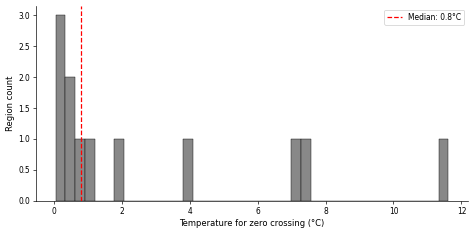

Figure 3: Distribution of Zero Crossing Temperatures

# 5 Slope Analysis

Maximum slope between 0 and 10°C: $\frac{dM}{dT} = \alpha + 2\beta T$

The maximum occurs at either T=0 or T=10 (endpoints of interval).

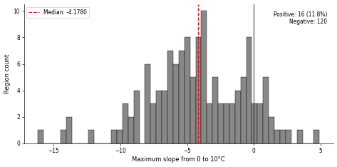

Figure 4: Distribution of Maximum Slopes (0-10°C)

*Convexity analysis omitted (beta constraint active).*

# 6 R-squared Analysis

## 6.1 Polynomial Fit Quality (rsqr1)

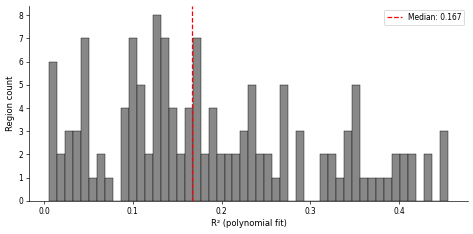

Figure 5: Regional Fit Quality (R-squared)

## 6.2 Error Model R-squared (rsqr2) Quantiles

Table 4: rsqr2 Quantiles

| 0% (Min) | 25% | 50% (Median) | 75% | 100% (Max) |
| --- | --- | --- | --- | --- |
| 0.4220 | 0.5308 | 0.5613 | 0.5874 | 0.6426 |

# 7 Modelled Variance

Modelled variance statistic: $1 - \frac{\sum_i \eta_i^2}{\sum_i D_i^2}$

Table 5: Modelled Variance Statistics

| Statistic | Value |
| --- | --- |
| Modelled variance | 0.7460 |
| Sum(η²) | 13278.9641 |
| Sum(D²) at T=3.0°C | 52279.0738 |
| N regions | 136 |

# 8 Best- and Worst-Fitting Regions

The 3 worst- and 3 best-fitting regions by R-squared, with raw simulation data overlaid on the fitted polynomial curve. **Red rows = worst fits**, **green rows = best fits**.

Table 6: Best- and worst-fitting regions

Top 3 best fit (R²) Top 3 worst fit (R²)

| Region | α | β | η | R² |
| --- | --- | --- | --- | --- |
| IRN | -10.1 | -1.11 | 10.4 | 0.456 |
| BWA | -12 | -1.84 | 14.4 | 0.448 |
| AFG | -16.2 | -0.00253 | 11.5 | 0.448 |
| BLR | -0.465 | -0.0131 | 4.71 | 0.0057 |
| LTU | 0.696 | -0.03 | 3.71 | 0.0105 |
| NLD | 1.5 | -0.185 | 4.18 | 0.0125 |

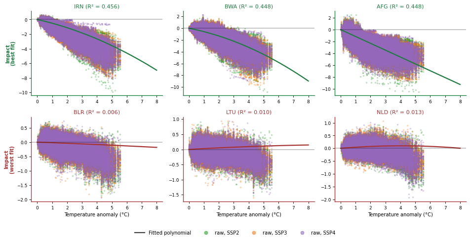

# 9 Regional Parameter Maps

Maps of key parameters at the **country** level. Red = negative (damage increases with T), Blue = positive.

## 9.1 Alpha (Linear Coefficient)

Alpha ($\alpha$) represents the linear sensitivity to temperature. Regions with negative alpha experience damage that increases with the first degree of warming.

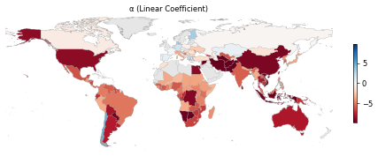

Figure 7: α (linear coefficient)

## 9.2 Beta (Quadratic Coefficient)

Beta ($\beta$) represents the curvature of the damage function.

The concavity ($\beta \leq 0$) constraint is enforced for this sector, meaning optimal temperature exists, damages accelerate beyond it.

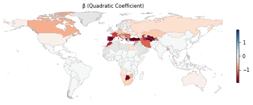

Figure 8: β (quadratic coefficient)

## 9.3 R-squared (Fit Quality)

$R^2$ measures the polynomial fit quality. Higher values indicate that the quadratic form captures more of the variance in the data.

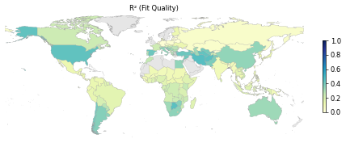

Figure 9: R² (stage 1 fit quality)

# 10 F2: Flex vs Raw Comparison

Comparison of flexible damage function predictions against raw simulation means.

For each scenario (RCP × SSP × Model), we compute at the final year:

- **Flex predicted**: $(\alpha \cdot T + \beta \cdot T^2) \cdot Y^\gamma$
- **Raw actual**: The outcome variable (y) from the source data

**Year 2098**: 1,457,280 rows

**rcp45**

**SSP2**

**high**

**Correlation:** 0.2952 | **RMSE:** 0.718324 | **Sign agreement:** 59.6%

[interactive chart not shown]

Top 5 best predicted Top 5 worst predicted

Year 2098 · T<sub>mean</sub> across these regions: 1.94°C

| Region | Raw | Flex | Residual |
| --- | --- | --- | --- |
| BIH | -0.408 | -0.408 | 4.83e-4 |
| GUY | -0.465 | -0.462 | 0.00222 |
| SUR | -0.37 | -0.376 | -0.00578 |
| RWA | -0.242 | -0.224 | 0.0172 |
| PER | -0.245 | -0.221 | 0.0237 |
| VNM | 1.17 | -0.718 | -1.89 |
| KHM | 1.33 | -0.489 | -1.82 |
| ECU | 1.1 | -0.471 | -1.57 |
| ESP | -1.8 | -0.35 | 1.45 |
| THA | 0.943 | -0.475 | -1.42 |

**low**

**Correlation:** 0.2161 | **RMSE:** 0.760755 | **Sign agreement:** 58.1%

[interactive chart not shown]

Top 5 best predicted Top 5 worst predicted

Year 2098 · T<sub>mean</sub> across these regions: 1.94°C

| Region | Raw | Flex | Residual |
| --- | --- | --- | --- |
| SUR | -0.392 | -0.397 | -0.00548 |
| MOZ | -0.695 | -0.713 | -0.0179 |
| LSO | -0.286 | -0.31 | -0.0239 |
| BIH | -0.416 | -0.386 | 0.0297 |
| SVN | -0.314 | -0.281 | 0.0327 |
| VNM | 1.12 | -0.761 | -1.88 |
| KHM | 1.28 | -0.555 | -1.83 |
| ECU | 1.13 | -0.564 | -1.7 |
| THA | 0.958 | -0.554 | -1.51 |
| PNG | 0.894 | -0.577 | -1.47 |

**SSP3**

**high**

**Correlation:** 0.2457 | **RMSE:** 0.769064 | **Sign agreement:** 58.1%

[interactive chart not shown]

Top 5 best predicted Top 5 worst predicted

Year 2098 · T<sub>mean</sub> across these regions: 1.94°C

| Region | Raw | Flex | Residual |
| --- | --- | --- | --- |
| LSO | -0.293 | -0.313 | -0.0205 |
| USA | -0.583 | -0.542 | 0.0407 |
| SUR | -0.414 | -0.464 | -0.0498 |
| MDA | -0.51 | -0.458 | 0.0521 |
| SVN | -0.325 | -0.27 | 0.055 |
| KHM | 1.35 | -0.692 | -2.04 |
| VNM | 1.11 | -0.913 | -2.02 |
| ECU | 1.06 | -0.621 | -1.69 |
| PNG | 0.899 | -0.665 | -1.56 |
| IDN | 0.704 | -0.856 | -1.56 |

**low**

**Correlation:** 0.1418 | **RMSE:** 0.884628 | **Sign agreement:** 55.9%

[interactive chart not shown]

Top 5 best predicted Top 5 worst predicted

Year 2098 · T<sub>mean</sub> across these regions: 1.94°C

| Region | Raw | Flex | Residual |
| --- | --- | --- | --- |
| MNG | -0.18 | -0.185 | -0.00453 |
| BIH | -0.423 | -0.412 | 0.011 |
| SVN | -0.318 | -0.296 | 0.0219 |
| ERI | -0.419 | -0.446 | -0.0274 |
| MNE | -0.242 | -0.181 | 0.0616 |
| KHM | 1.39 | -0.722 | -2.11 |
| VNM | 1.13 | -0.91 | -2.04 |
| GIN | 0.693 | -1.29 | -1.99 |
| ECU | 1.01 | -0.731 | -1.74 |
| PNG | 0.927 | -0.749 | -1.68 |

**SSP4**

**high**

**Correlation:** 0.2013 | **RMSE:** 0.782086 | **Sign agreement:** 57.4%

[interactive chart not shown]

Top 5 best predicted Top 5 worst predicted

Year 2098 · T<sub>mean</sub> across these regions: 1.94°C

| Region | Raw | Flex | Residual |
| --- | --- | --- | --- |
| GUY | -0.457 | -0.453 | 0.00392 |
| BIH | -0.409 | -0.404 | 0.00576 |
| SUR | -0.374 | -0.384 | -0.00957 |
| SWZ | -0.487 | -0.477 | 0.0101 |
| PER | -0.242 | -0.221 | 0.0205 |
| KHM | 1.31 | -0.744 | -2.06 |
| VNM | 1.04 | -0.731 | -1.77 |
| PNG | 0.985 | -0.739 | -1.72 |
| ECU | 1.09 | -0.489 | -1.58 |
| LAO | 0.872 | -0.6 | -1.47 |

**low**

**Correlation:** 0.2027 | **RMSE:** 0.811917 | **Sign agreement:** 57.4%

[interactive chart not shown]

Top 5 best predicted Top 5 worst predicted

Year 2098 · T<sub>mean</sub> across these regions: 1.94°C

| Region | Raw | Flex | Residual |
| --- | --- | --- | --- |
| SWZ | -0.47 | -0.471 | -3.65e-4 |
| SVN | -0.302 | -0.285 | 0.0173 |
| ERI | -0.404 | -0.376 | 0.0286 |
| BIH | -0.396 | -0.427 | -0.031 |
| MNG | -0.203 | -0.155 | 0.0472 |
| KHM | 1.34 | -0.707 | -2.05 |
| VNM | 1.1 | -0.907 | -2.01 |
| ECU | 1.07 | -0.7 | -1.77 |
| PNG | 0.913 | -0.7 | -1.61 |
| GIN | 0.594 | -1.01 | -1.6 |

**rcp85**

**SSP2**

**high**

**Correlation:** 0.4161 | **RMSE:** 1.493012 | **Sign agreement:** 58.1%

[interactive chart not shown]

Top 5 best predicted Top 5 worst predicted

Year 2098 · T<sub>mean</sub> across these regions: 4.17°C

| Region | Raw | Flex | Residual |
| --- | --- | --- | --- |
| RWA | -0.499 | -0.482 | 0.017 |
| USA | -1.17 | -1.15 | 0.0171 |
| BOL | -1.15 | -1.1 | 0.0497 |
| GEO | -1.19 | -1.14 | 0.0588 |
| MWI | -0.921 | -0.859 | 0.0619 |
| VNM | 1.95 | -1.54 | -3.49 |
| KHM | 2.44 | -1.05 | -3.49 |
| ISR | -4.17 | -1.23 | 2.94 |
| LAO | 1.99 | -0.838 | -2.83 |
| THA | 1.81 | -1.02 | -2.83 |

**low**

**Correlation:** 0.3293 | **RMSE:** 1.557627 | **Sign agreement:** 58.8%

[interactive chart not shown]

Top 5 best predicted Top 5 worst predicted

Year 2098 · T<sub>mean</sub> across these regions: 4.17°C

| Region | Raw | Flex | Residual |
| --- | --- | --- | --- |
| GEO | -1.18 | -1.17 | 0.015 |
| SUR | -0.83 | -0.853 | -0.0228 |
| CHE | -0.719 | -0.648 | 0.0702 |
| PER | -0.539 | -0.622 | -0.0832 |
| USA | -1.21 | -1.1 | 0.111 |
| KHM | 2.31 | -1.19 | -3.51 |
| VNM | 1.81 | -1.63 | -3.45 |
| LAO | 1.8 | -1.13 | -2.93 |
| THA | 1.73 | -1.19 | -2.92 |
| PNG | 1.63 | -1.24 | -2.87 |

**SSP3**

**high**

**Correlation:** 0.3600 | **RMSE:** 1.576891 | **Sign agreement:** 58.1%

[interactive chart not shown]

Top 5 best predicted Top 5 worst predicted

Year 2098 · T<sub>mean</sub> across these regions: 4.17°C

| Region | Raw | Flex | Residual |
| --- | --- | --- | --- |
| PAK | -3.24 | -3.24 | 0.00418 |
| USA | -1.16 | -1.19 | -0.0291 |
| PER | -0.56 | -0.601 | -0.0406 |
| CHE | -0.713 | -0.663 | 0.0504 |
| AFG | -4.21 | -4.11 | 0.0957 |
| VNM | 1.76 | -1.96 | -3.72 |
| KHM | 2.2 | -1.49 | -3.69 |
| IDN | 1.28 | -1.84 | -3.12 |
| THA | 1.68 | -1.32 | -3 |
| ISR | -4.31 | -1.37 | 2.93 |

**low**

**Correlation:** 0.2020 | **RMSE:** 1.818134 | **Sign agreement:** 55.9%

[interactive chart not shown]

Top 5 best predicted Top 5 worst predicted

Year 2098 · T<sub>mean</sub> across these regions: 4.17°C

| Region | Raw | Flex | Residual |
| --- | --- | --- | --- |
| USA | -1.13 | -1.11 | 0.0195 |
| SWZ | -1.32 | -1.28 | 0.0389 |
| CHE | -0.683 | -0.634 | 0.0492 |
| GEO | -1.16 | -1.22 | -0.0635 |
| SYR | -4.55 | -4.66 | -0.106 |
| GIN | 1.31 | -2.78 | -4.09 |
| KHM | 2.32 | -1.55 | -3.87 |
| VNM | 1.86 | -1.96 | -3.82 |
| CAF | 1.55 | -1.9 | -3.45 |
| LBR | 1.3 | -2.14 | -3.43 |

**SSP4**

**high**

**Correlation:** 0.2485 | **RMSE:** 1.661837 | **Sign agreement:** 56.6%

[interactive chart not shown]

Top 5 best predicted Top 5 worst predicted

Year 2098 · T<sub>mean</sub> across these regions: 4.17°C

| Region | Raw | Flex | Residual |
| --- | --- | --- | --- |
| LSO | -0.748 | -0.763 | -0.0149 |
| BOL | -1.21 | -1.2 | 0.0162 |
| SUR | -0.889 | -0.824 | 0.0645 |
| GEO | -1.21 | -1.1 | 0.111 |
| PER | -0.597 | -0.476 | 0.121 |
| KHM | 2.33 | -1.6 | -3.93 |
| VNM | 1.83 | -1.57 | -3.4 |
| PNG | 1.64 | -1.59 | -3.23 |
| TLS | 0.24 | -2.94 | -3.18 |
| LBR | 1.38 | -1.72 | -3.1 |

**low**

**Correlation:** 0.2652 | **RMSE:** 1.704935 | **Sign agreement:** 56.6%

[interactive chart not shown]

Top 5 best predicted Top 5 worst predicted

Year 2098 · T<sub>mean</sub> across these regions: 4.17°C

| Region | Raw | Flex | Residual |
| --- | --- | --- | --- |
| CHE | -0.722 | -0.632 | 0.0894 |
| USA | -1.17 | -1.08 | 0.0949 |
| GEO | -1.18 | -1.29 | -0.11 |
| ERI | -0.695 | -0.807 | -0.112 |
| SUR | -0.907 | -1.03 | -0.123 |
| KHM | 2.39 | -1.52 | -3.91 |
| VNM | 1.87 | -1.95 | -3.81 |
| GIN | 1.3 | -2.16 | -3.47 |
| THA | 1.77 | -1.47 | -3.24 |
| LAO | 1.74 | -1.43 | -3.17 |

## 10.1 Scenario Summary

Table 7: Fit statistics across all 12 scenarios

| RCP | SSP | Model | N | Corr | RMSE | Sign% |
| --- | --- | --- | --- | --- | --- | --- |
| rcp45 | SSP2 | high | 136 | 0.2952 | 0.718324 | 59.6% |
| rcp45 | SSP2 | low | 136 | 0.2161 | 0.760755 | 58.1% |
| rcp45 | SSP3 | high | 136 | 0.2457 | 0.769064 | 58.1% |
| rcp45 | SSP3 | low | 136 | 0.1418 | 0.884628 | 55.9% |
| rcp45 | SSP4 | high | 136 | 0.2013 | 0.782086 | 57.4% |
| rcp45 | SSP4 | low | 136 | 0.2027 | 0.811917 | 57.4% |
| rcp85 | SSP2 | high | 136 | 0.4161 | 1.49301 | 58.1% |
| rcp85 | SSP2 | low | 136 | 0.3293 | 1.55763 | 58.8% |
| rcp85 | SSP3 | high | 136 | 0.36 | 1.57689 | 58.1% |
| rcp85 | SSP3 | low | 136 | 0.202 | 1.81813 | 55.9% |
| rcp85 | SSP4 | high | 136 | 0.2485 | 1.66184 | 56.6% |
| rcp85 | SSP4 | low | 136 | 0.2652 | 1.70494 | 56.6% |

# 11 Data Reference

## 11.1 File Locations

| Item | Path |
| --- | --- |
| Regional CSV | `/project/cil/gcp/flex_damage_funcs/parameters/agriculture__soy_country__regional_parameters.csv` |
| Global JSON | `/project/cil/gcp/flex_damage_funcs/parameters/agriculture__soy_country__global_results.json` |
| Metadata JSON | `/project/cil/gcp/flex_damage_funcs/parameters/agriculture__soy_country__metadata.json` |

## 11.2 Column Definitions

| Column | Description |
| --- | --- |
| `region` | Region identifier (hierarchical code, first 3 chars = country ISO3) |
| `gamma` | Income elasticity quantile value |
| `alpha` | Linear temperature coefficient |
| `beta` | Quadratic temperature coefficient |
| `sigma11` | Var(alpha) |
| `sigma12` | Cov(alpha, beta) |
| `sigma22` | Var(beta) |
| `rho` | Correlation with global residual process |
| `zeta` | Temperature-dependent heteroskedasticity |
| `eta` | Residual standard deviation |
| `rsqr1` | R-squared of polynomial fit |
| `rsqr2` | R-squared of error model |

*Report generated with FlexDamage v1.0.0*